# Ejemplo de Gloria

Gloria Vizcaíno

5/11/2021

Carga del script con las funciones que usaré:

```r
source("teoriadecision_funciones_incertidumbre.R")
```

Función que da la mejor alternativa según el valor de alfa:

```r
alfas = function(tablaX, precisionAlfa=0.05, favorable=TRUE){
  X = tablaX;
  Altmin = apply(X,MARGIN=1,min);
  Altmax = apply(X,MARGIN=1,max);
  valfa = seq(from=0,to=1,by=precisionAlfa);
  vHurwicz = rep(0,length(valfa));
  alternativa = rep(0,length(valfa));
  Alt_vHurwicz = rep(0,length(valfa));
  for (i in 1:length(valfa)) {
    alfab = valfa[i];
    if (favorable) {
      vAltH = alfab * Altmax + (1-alfab) * Altmin;
      vHurwicz[i] = max(vAltH)
      alternativa[i]=which.max(vAltH) #que alternativa lo cumple
    } else {
      vAltH = alfab * Altmin + (1-alfab) * Altmax;
      vHurwicz[i] = min(vAltH)
      alternativa[i]=which.min(vAltH) #que alternativa lo cumple
    }

  }

  altsinrep=unique(alternativa) #me quedo con las diferentes alternativas (quitando las repeticiones)
  alfasb = (which(!duplicated(alternativa)))*precisionAlfa - precisionAlfa
  #posiciones de cuándo aparecen las nuevas alternativas en el intervalo [0,1] (alfas)
  alfas=alfasb[-1] #quitamos la primera que siempre será 0)

  #salida que se nos pide:
  return(

  if (length(alfas)==1) {
    cat ("La mejor alternativa es",altsinrep[1],
         "para alfa perteneciente a [ 0 ,",alfas[1],
         "] y la mejor alternativa es",altsinrep[2],
         "para alfa perteneciente a [",alfas[1],", 1 ]")
    } else {
    if (length(alfas)==2) {
      cat ("La mejor alternativa es",altsinrep[1],
           "para alfa perteneciente a [ 0 ,",
           alfas[1],"], la mejor alternativa es",altsinrep[2],
           "para alfa perteneciente a [",alfas[1],",",alfas[2],
           "] y la mejor alternativa es", altsinrep[3],
           "si alfa pertenece a [",alfas[2],", 1 ]")
    } else {
      cat ("La mejor alternativa es",altsinrep[1],
           "para alfa perteneciente a [ 0 ,",alfas[1],"], ")
      for (i in 1:(length(alfas)-1)) {
        cat ("la mejor alternativa es",altsinrep[i+1],
             "para alfa perteneciente a [",alfas[i],",",alfas[i+1],"] ")
      }
      cat ("y la mejor alternativa es", altsinrep[length(altsinrep)],
           "si alfa pertenece a [",alfas[length(alfas)],", 1 ]")
      }
    }
  )

} #fin de función creada
```

# ENUNCIADO:

Una persona quiere tomar la decisión de qué medio de transporte usar para ir diariamente a trabajar. Las alternativas son las siguientes: coche, autobús, patinete eléctrico y metro.

El dinero que ahorraría el trabajador (expresado en euros) usando cada uno de los transportes varía según:

E1: va al trabajo en dicho transporte y vuelve andando.

E2: va al travajo andando y vuelve en dicho transporte.

E3: va y vuelve del trabajo en dicho transporte.

E4: va y vuelve al trabajo en dicho transporte repartiendo gastos (si es posible) con un compañero de trabajo.

Y se recoge en la siguiente tabla:

[output not shown]

¿Qué transporte sería la mejor opción (con el que más ahorre) para ir atrabajar?

# SOLUCIÓN:

Objetivo: maximizar ahorro.

Planteamiento:

- Un decisor
- Modelo favorable

Alternativas:

- 1=“Coche”
- 2=“Autobús”
- 3=“Patinete eléctrico”
- 4=“Metro”

Estados de la naturaleza:

- E1 = “va al trabajo en dicho transporte y vuelve andando”
- E2 = “va al trabajo andando y vuelve en dicho transporte”
- E3 = “va y vuelve del trabajo en dicho transporte”
- E4 = “va y vuelve al trabajo en dicho transporte repartiendo gastos (si es posible) con un compañero de trabajo”

## Resolución en R:

En primer lugar preparamos los datos y le aplicamos todos los criterios de incertidumbre estudiados para conocer cuál es la mejor alternativa en cada caso:

```r
t2=crea.tablaX(c(24,27,10,16,16,16,16,16,23,23,21,15,25,24,14,14),4,4)
criterio.Todos(t2, alfa=0.3,favorable = TRUE)
```

```
##                 e1 e2 e3 e4 Wald Optimista Hurwicz Savage Laplace Punto Ideal
## d1              24 27 10 16   10        27    15.1     11   19.25      11.045
## d2              16 16 16 16   16        16    16.0     11   16.00      15.067
## d3              23 23 21 15   15        23    17.4      4   20.50       4.583
## d4              25 24 14 14   14        25    17.3      7   19.25       7.874
## iAlt.Opt (fav.) -- -- -- --   d2        d1      d3     d3      d3          d3
```

Según el criterio de Wald la mejor alternativa es la 2 (Autobús), según el criterio optimista la mejor alternativa es la 1 (coche) y según los demás criterios la mejor alternativa es la 3 (Patinete Eléctrico).

NOTA: se ha aplicado el criterio de Hurwicz para alfa=0.3, vamos a ver ahora cómo varía para los diferentes valores de alfa:

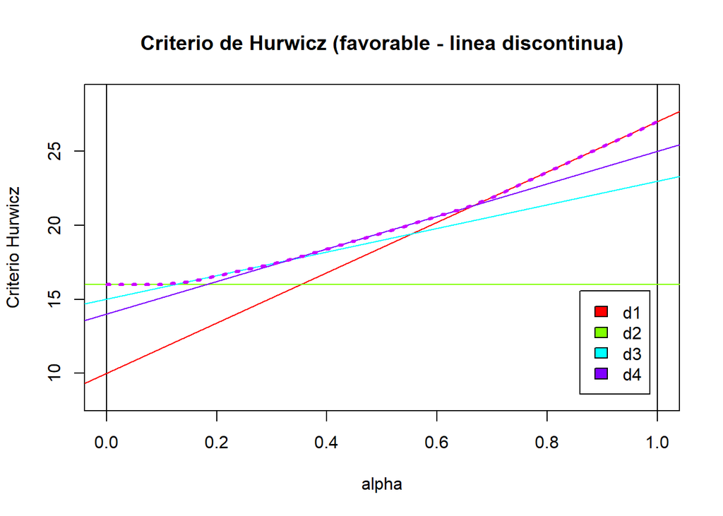

```r
dibuja.criterio.Hurwicz(t2,favorable=TRUE)
```

```r
alfas(t2,precisionAlfa = 0.05,favorable = TRUE)
```

```
## La mejor alternativa es 2 para alfa perteneciente a [ 0 , 0.15 ], la mejor alternativa es 3 para alfa perteneciente a [ 0.15 , 0.35 ] la mejor alternativa es 4 para alfa perteneciente a [ 0.35 , 0.7 ] y la mejor alternativa es 1 si alfa pertenece a [ 0.7 , 1 ]
```

Hago lo mismo con una mayor precisión en los valores del alfa:

```r
alfas(t2,precisionAlfa = 0.001,favorable = TRUE)
```

```
## La mejor alternativa es 2 para alfa perteneciente a [ 0 , 0.126 ], la mejor alternativa es 3 para alfa perteneciente a [ 0.126 , 0.334 ] la mejor alternativa es 4 para alfa perteneciente a [ 0.334 , 0.667 ] y la mejor alternativa es 1 si alfa pertenece a [ 0.667 , 1 ]
```